# Tutorial 6: Basic Statistical Analysis in R

Descriptive Statistics · Hypothesis Testing · Correlation · Statistical Report

2026-02-22

# About This Tutorial

In this tutorial we will perform a full statistical analysis on a real medical dataset, step by step.

By the end of this session you will be able to:

- Explore and summarize a dataset using descriptive statistics
- Run and interpret a t-test and a chi-square test
- Compute and visualize a correlation matrix
- Understand how this document *itself* is a statistical report

**Dataset:** `Pima.tr` from the `MASS` package — diabetes data from Pima Indian women.

# Part 0 — Setup

## Load Packages

```r
library(MASS)    # contains the Pima.tr dataset
library(psych)   # describe() and describeBy()
library(ggpubr)  # ggscatter() for correlation plots
```

## Load the Data

```r
data(Pima.tr)
```

## Variable Reference

| Variable | Description | Type |
| --- | --- | --- |
| `npreg` | Number of pregnancies | Continuous |
| `glu` | Plasma glucose concentration | Continuous |
| `bp` | Diastolic blood pressure (mm Hg) | Continuous |
| `skin` | Triceps skin fold thickness (mm) | Continuous |
| `bmi` | Body mass index | Continuous |
| `ped` | Diabetes pedigree function (family history score) | Continuous |
| `age` | Age (years) | Continuous |
| `type` | Diabetes diagnosis | Categorical (Yes / No) |

# Part 1 — First Look at the Data

## Basic Exploration

```r
# Dimensions: how many rows and columns?
dim(Pima.tr)
```

```
## [1] 200   8
```

```r
# First 6 rows
head(Pima.tr)
```

|  | npreg | glu | bp | skin | bmi | ped | age | type |
| --- | --- | --- | --- | --- | --- | --- | --- | --- |
| 1 | 5 | 86 | 68 | 28 | 30.2 | 0.364 | 24 | No |
| 2 | 7 | 195 | 70 | 33 | 25.1 | 0.163 | 55 | Yes |
| 3 | 5 | 77 | 82 | 41 | 35.8 | 0.156 | 35 | No |
| 4 | 0 | 165 | 76 | 43 | 47.9 | 0.259 | 26 | No |
| 5 | 0 | 107 | 60 | 25 | 26.4 | 0.133 | 23 | No |
| 6 | 5 | 97 | 76 | 27 | 35.6 | 0.378 | 52 | Yes |

```r
# Variable types and structure
str(Pima.tr)
```

```
## 'data.frame':    200 obs. of  8 variables:
##  $ npreg: int  5 7 5 0 0 5 3 1 3 2 ...
##  $ glu  : int  86 195 77 165 107 97 83 193 142 128 ...
##  $ bp   : int  68 70 82 76 60 76 58 50 80 78 ...
##  $ skin : int  28 33 41 43 25 27 31 16 15 37 ...
##  $ bmi  : num  30.2 25.1 35.8 47.9 26.4 35.6 34.3 25.9 32.4 43.3 ...
##  $ ped  : num  0.364 0.163 0.156 0.259 0.133 ...
##  $ age  : int  24 55 35 26 23 52 25 24 63 31 ...
##  $ type : Factor w/ 2 levels "No","Yes": 1 2 1 1 1 2 1 1 1 2 ...
```

## How Many Diabetic vs. Non-Diabetic?

```r
# Count per group
table(Pima.tr$type)
```

```
##
##  No Yes
## 132  68
```

```r
# Proportions
prop.table(table(Pima.tr$type))
```

```
##
##   No  Yes
## 0.66 0.34
```

## Missing Values

```r
# Total missing values in the dataset
sum(is.na(Pima.tr))
```

```
## [1] 0
```

```r
# Missing values per column
colSums(is.na(Pima.tr))
```

```
## npreg   glu    bp  skin   bmi   ped   age  type
##     0     0     0     0     0     0     0     0
```

> 🖊️ **Try it yourself:** What type of variable is `type`? What type is `glu`? Is this dataset balanced between the two groups?

# Part 2 — Descriptive Statistics

## Summary of the Entire Dataset

```r
summary(Pima.tr)
```

```
##      npreg            glu              bp              skin
##  Min.   : 0.00   Min.   : 56.0   Min.   : 38.00   Min.   : 7.00
##  1st Qu.: 1.00   1st Qu.:100.0   1st Qu.: 64.00   1st Qu.:20.75
##  Median : 2.00   Median :120.5   Median : 70.00   Median :29.00
##  Mean   : 3.57   Mean   :124.0   Mean   : 71.26   Mean   :29.21
##  3rd Qu.: 6.00   3rd Qu.:144.0   3rd Qu.: 78.00   3rd Qu.:36.00
##  Max.   :14.00   Max.   :199.0   Max.   :110.00   Max.   :99.00
##       bmi             ped              age         type
##  Min.   :18.20   Min.   :0.0850   Min.   :21.00   No :132
##  1st Qu.:27.57   1st Qu.:0.2535   1st Qu.:23.00   Yes: 68
##  Median :32.80   Median :0.3725   Median :28.00
##  Mean   :32.31   Mean   :0.4608   Mean   :32.11
##  3rd Qu.:36.50   3rd Qu.:0.6160   3rd Qu.:39.25
##  Max.   :47.90   Max.   :2.2880   Max.   :63.00
```

## Detailed Statistics with psych

`psych::describe()` gives us more: mean, SD, median, skewness, kurtosis, and more — all in one table.

```r
describe(Pima.tr[, -8])  # exclude the categorical variable 'type'
```

|  | vars | n | mean | sd | median | trimmed | mad | min | max | range | skew | kurtosis | se |
| --- | --- | --- | --- | --- | --- | --- | --- | --- | --- | --- | --- | --- | --- |
| npreg | 1 | 200 | 3.570000 | 3.3662678 | 2.0000 | 3.1062500 | 2.9652000 | 0.000 | 14.000 | 14.000 | 1.09014511 | 0.4404379 | 0.23803108 |
| glu | 2 | 200 | 123.970000 | 31.6672254 | 120.5000 | 122.0812500 | 31.8759000 | 56.000 | 199.000 | 143.000 | 0.44942066 | -0.3818467 | 2.23921098 |
| bp | 3 | 200 | 71.260000 | 11.4796039 | 70.0000 | 71.1312500 | 11.8608000 | 38.000 | 110.000 | 72.000 | 0.16403848 | 0.5072787 | 0.81173058 |
| skin | 4 | 200 | 29.215000 | 11.7245940 | 29.0000 | 28.8000000 | 11.8608000 | 7.000 | 99.000 | 92.000 | 1.08492620 | 4.8766371 | 0.82905400 |
| bmi | 5 | 200 | 32.310000 | 6.1302119 | 32.8000 | 32.2600000 | 6.5234400 | 18.200 | 47.900 | 29.700 | 0.02494172 | -0.4353011 | 0.43347144 |
| ped | 6 | 200 | 0.460765 | 0.3072248 | 0.3725 | 0.4187375 | 0.2290617 | 0.085 | 2.288 | 2.203 | 1.94024872 | 6.4897616 | 0.02172408 |
| age | 7 | 200 | 32.110000 | 10.9754363 | 28.0000 | 30.4625000 | 8.8956000 | 21.000 | 63.000 | 42.000 | 1.07982909 | 0.2343962 | 0.77608054 |

**Key columns to focus on:**

- `mean` / `median` — are they close? If not, the distribution may be skewed
- `sd` — how spread out are the values?
- `skew` — positive skew means a long right tail
- `min` / `max` — are there suspicious extreme values?

## Descriptive Statistics by Group

Now let’s split by diabetes status to compare the two groups:

```r
describeBy(Pima.tr[, -8], group = Pima.tr$type)
```

```
##
##  Descriptive statistics by group
## group: No
##       vars   n   mean    sd median trimmed   mad   min   max  range skew
## npreg    1 132   2.92  2.81   2.00    2.47  1.48  0.00  13.0  13.00 1.53
## glu      2 132 113.11 26.64 109.50  111.46 21.50 56.00 193.0 137.00 0.62
## bp       3 132  69.55 11.08  70.00   69.37 10.38 38.00 110.0  72.00 0.25
## skin     4 132  27.20 10.93  27.00   26.73 13.34  8.00  60.0  52.00 0.39
## bmi      5 132  31.07  6.38  31.05   30.88  7.19 18.20  47.9  29.70 0.29
## ped      6 132   0.42  0.27   0.32    0.38  0.19  0.09   1.7   1.61 1.52
## age      7 132  29.23  9.54  26.00   27.46  5.93 21.00  63.0  42.00 1.70
##       kurtosis   se
## npreg     2.16 0.24
## glu       0.45 2.32
## bp        0.64 0.96
## skin     -0.54 0.95
## bmi      -0.40 0.56
## ped       3.24 0.02
## age       2.53 0.83
## ------------------------------------------------------------
## group: Yes
##       vars  n   mean    sd median trimmed   mad   min    max  range  skew
## npreg    1 68   4.84  3.97   4.50    4.54  5.19  0.00  14.00  14.00  0.41
## glu      2 68 145.06 30.12 144.00  145.14 34.10 80.00 199.00 119.00  0.02
## bp       3 68  74.59 11.58  76.00   74.46 11.86 40.00 106.00  66.00 -0.03
## skin     4 68  33.12 12.30  32.00   32.71  8.90  7.00  99.00  92.00  2.02
## bmi      5 68  34.71  4.81  34.60   34.75  4.45 22.90  46.10  23.20 -0.10
## ped      6 68   0.55  0.36   0.45    0.50  0.29  0.15   2.29   2.14  2.03
## age      7 68  37.69 11.48  36.00   37.12 11.86 21.00  62.00  41.00  0.36
##       kurtosis   se
## npreg    -0.89 0.48
## glu      -0.90 3.65
## bp        0.59 1.40
## skin     10.07 1.49
## bmi      -0.11 0.58
## ped       6.42 0.04
## age      -0.95 1.39
```

> 🖊️ **Try it yourself:** Looking at the two tables above — which variable shows the most visible difference between diabetic and non-diabetic women? Does this make clinical sense?

# Part 3 — Hypothesis Testing

## 3.1 — t-test: BMI in Diabetic vs. Non-Diabetic Women

**Research question:** Is there a statistically significant difference in BMI between women with and without diabetes?

**Hypotheses:**

- H₀: The mean BMI is equal in both groups
- H₁: The mean BMI is different between groups

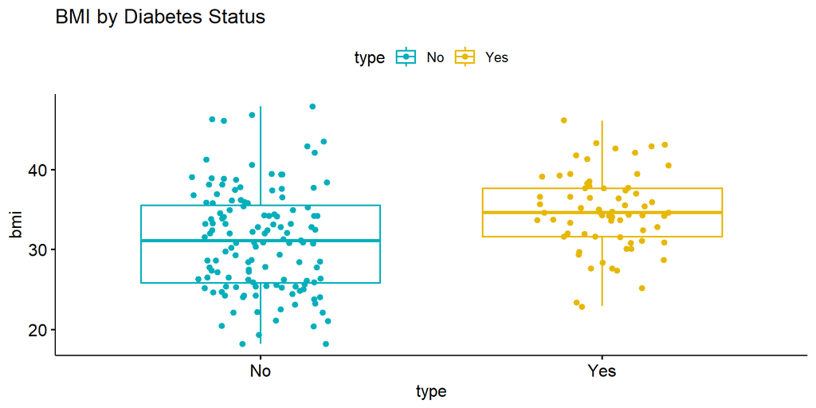

```r
# Visualize before testing
ggboxplot(Pima.tr,
          x     = "type",
          y     = "bmi",
          color = "type",
          palette = c("#00AFBB", "#E7B800"),
          add   = "jitter",
          title = "BMI by Diabetes Status")
```

```r
# Run the t-test
t.test(bmi ~ type, data = Pima.tr)
```

```
##
##  Welch Two Sample t-test
##
## data:  bmi by type
## t = -4.512, df = 171.46, p-value = 1.188e-05
## alternative hypothesis: true difference in means between group No and group Yes is not equal to 0
## 95 percent confidence interval:
##  -5.224615 -2.044547
## sample estimates:
##  mean in group No mean in group Yes
##          31.07424          34.70882
```

**How to read this output:**

| Element | What it means |
| --- | --- |
| `t` | Test statistic — how many SEs away from zero |
| `df` | Degrees of freedom |
| `p-value` | If < 0.05 → reject H₀ |
| `95% CI` | Plausible range for the true difference in means |
| `mean in group No/Yes` | Group means |

> 🖊️ **Try it yourself:** Repeat the t-test using `glu` (glucose) instead of `bmi`. What is your conclusion? Is it stronger or weaker than the BMI result?

```r
# Your code here:
```

## 3.2 — Chi-Square Test: Age Group and Diabetes

**Research question:** Is there an association between age group and diabetes diagnosis?

First, we create a new binary variable:

```r
# Create age group variable: Young (< 35) vs. Older (>= 35)
Pima.tr$age_group <- ifelse(Pima.tr$age < 35, "Young (<35)", "Older (>=35)")

# Check the distribution
table(Pima.tr$age_group)
```

```
##
## Older (>=35)  Young (<35)
##           64          136
```

Now create a contingency table and run the chi-square test:

```r
# Contingency table
age_diabetes_table <- table(Pima.tr$age_group, Pima.tr$type)
age_diabetes_table
```

```
##
##                 No Yes
##   Older (>=35)  28  36
##   Young (<35)  104  32
```

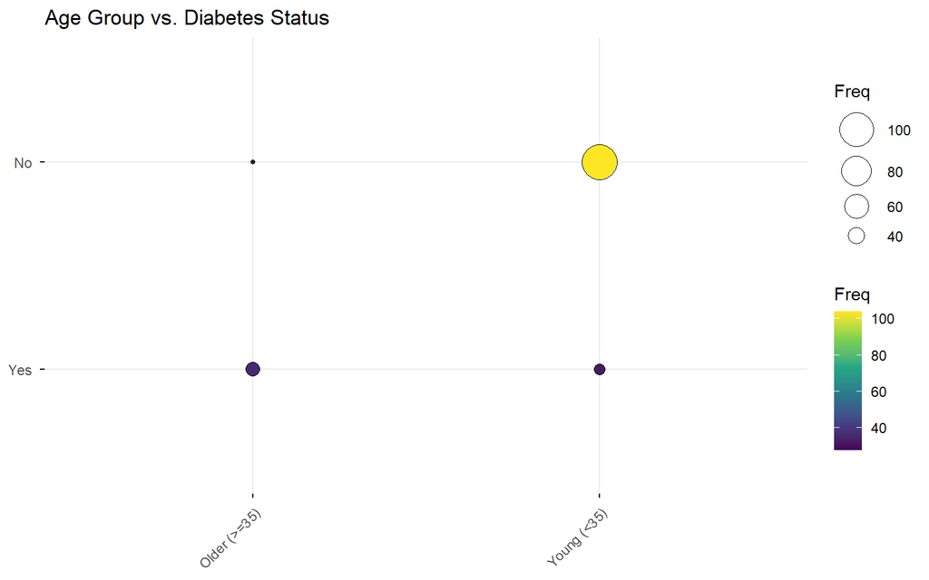

```r
# Visualize
ggballoonplot(as.data.frame(age_diabetes_table),
              fill = "value",
              title = "Age Group vs. Diabetes Status") +
  scale_fill_viridis_c()
```

```r
# Chi-square test
chisq.test(age_diabetes_table)
```

```
##
##  Pearson's Chi-squared test with Yates' continuity correction
##
## data:  age_diabetes_table
## X-squared = 19.331, df = 1, p-value = 1.099e-05
```

**How to read this output:**

| Element | What it means |
| --- | --- |
| `X-squared` | Test statistic |
| `df` | Degrees of freedom (always (rows-1)×(cols-1)) |
| `p-value` | If < 0.05 → association exists between the two variables |

> 🖊️ **Try it yourself:** What is the clinical interpretation of this result? Is being older associated with higher diabetes rates in this dataset? Look at the contingency table to support your answer.

# Part 4 — Correlation Analysis

## Correlation Matrix

```r
# Pearson correlation matrix for all continuous variables
cor_matrix <- cor(Pima.tr[, 1:7], use = "complete.obs")
round(cor_matrix, 2)
```

```
##       npreg  glu    bp skin  bmi   ped   age
## npreg  1.00 0.17  0.25 0.11 0.06 -0.12  0.60
## glu    0.17 1.00  0.27 0.22 0.22  0.06  0.34
## bp     0.25 0.27  1.00 0.26 0.24 -0.05  0.39
## skin   0.11 0.22  0.26 1.00 0.66  0.10  0.25
## bmi    0.06 0.22  0.24 0.66 1.00  0.19  0.13
## ped   -0.12 0.06 -0.05 0.10 0.19  1.00 -0.07
## age    0.60 0.34  0.39 0.25 0.13 -0.07  1.00
```

## Visualize the Correlation Matrix

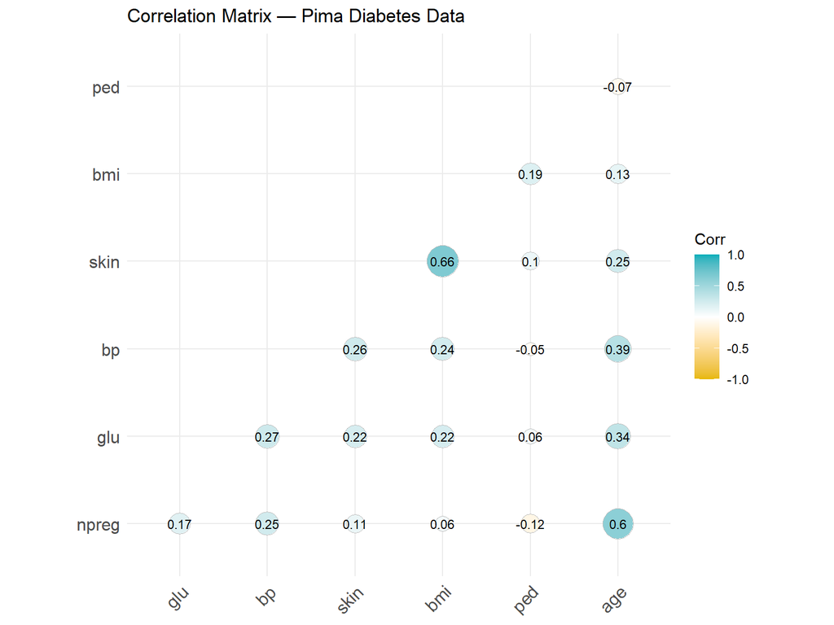

```r
# Heatmap using ggcorrplot (via ggpubr helper)
library(ggcorrplot)

ggcorrplot(cor_matrix,
           method   = "circle",
           type     = "lower",
           lab      = TRUE,
           lab_size = 3,
           colors   = c("#E7B800", "white", "#00AFBB"),
           title    = "Correlation Matrix — Pima Diabetes Data")
```

## Scatter Plot: Glucose vs. BMI

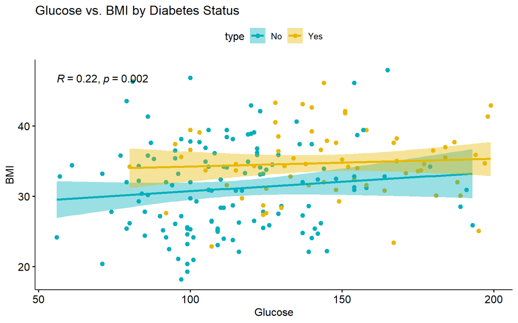

```r
ggscatter(Pima.tr,
          x         = "glu",
          y         = "bmi",
          color     = "type",
          palette   = c("#00AFBB", "#E7B800"),
          add       = "reg.line",
          conf.int  = TRUE,
          cor.coef  = TRUE,
          cor.method = "pearson",
          xlab      = "Glucose",
          ylab      = "BMI",
          title     = "Glucose vs. BMI by Diabetes Status")
```

> 🖊️ **Try it yourself:** Look at the correlation matrix. Which pair of variables has the strongest correlation? Pick one other pair that interests you clinically and create a scatter plot for it.

```r
# Your code here:
```

# Part 5 — The Statistical Report

## What Makes a Good Statistical Report?

Look at what we have built so far in this document:

1. **Research context** — we described the dataset and variables
2. **Descriptive statistics** — we summarized the data overall and by group
3. **Hypothesis tests** — we tested specific clinical questions
4. **Visualizations** — we supported every analysis with a plot
5. **Interpretation** — we explained what the numbers mean

**This document *is* the report.** That is the power of R Markdown.

## Structure of a Statistical Report

A good report follows this structure for each analysis:

```
1. Research question
2. Hypothesis (H₀ and H₁)
3. Method chosen and why
4. Results (test statistic, p-value, CI)
5. Interpretation in plain language
6. Clinical meaning
```

## Example: Writing Up the BMI t-test

> 🖊️ **Try it yourself:** Write a similar paragraph for the glucose t-test you ran in Part 3. Include: the two group means, the p-value, the CI, and one sentence of clinical interpretation.

# Knit This Document

When you are ready:

1. Click the **Knit** button at the top of RStudio
2. Choose **Knit to HTML**
3. Your full report will open in the browser

Every time you change something in the analysis — just knit again. The report updates automatically.

# Summary

| Topic | What we did | Key function |
| --- | --- | --- |
| Exploration | Looked at structure and missingness | `str()`, `summary()` |
| Descriptive stats | Mean, SD, skew by group | `describe()`, `describeBy()` |
| t-test | Compared means between two groups | `t.test()` |
| Chi-square | Tested association between categoricals | `chisq.test()` |
| Correlation | Measured linear relationships | `cor()`, `ggscatter()` |
| Report | Knitted everything to HTML | `Rmd → Knit` |

> **Key message to take home:** A p-value tells you *whether* an effect exists. A confidence interval tells you *how large* it plausibly is. Always report both — and always interpret in clinical context.